# Homework 2

BUS 32100

Section 01 Due 11:59PM Oct 17 2019 Section 85 Due 11:59PM Oct 18 2019

# Instructions:

It is recommended that you collaborate with your classmates on this assignment. However, you must type **your own** code and submit your source file in either`.html` or `.Rmd` format on Canvas.

In some cases, a **incomplete code** is given to guide you in the right direction. However, you will need to fill in the blanks in order to run the code block. Make sure to fill **all the blanks**, or comment them out, before you knit your R markdown file. Otherwise, it will return knitting errors. Challenge questions are for practise and extra credits. If you choose not to answer them, remove the `r` code block to avoid error messages.

# 1. Data wrangling and visualization with college data

We will explore data on college majors and earnings, specifically the data behind the FiveThirtyEight story [“The Economic Guide To Picking A College Major”](https://fivethirtyeight.com/features/the-economic-guide-to-picking-a-college-major/).

This week we will use the `read_csv` function to read in our csv file:

We read it in with the `read_csv` function, and save the result as a new data frame called `college_recent_grads`. Because `read_csv` is a function from `tidyverse`, this new data frame will be a tidy data frame.

```r
college_recent_grads <- read_csv(
  "https://raw.githubusercontent.com/BUSN32100/data_files/master/recent-grads.csv"
  )
```

`college_recent_grads` is a tidy **data frame**, with each row representing an **observation** and each column representing a **variable**.

To view the data, you can take a quick peek at your data frame and view its dimensions with the `glimpse` function.

```r
glimpse(college_recent_grads)
```

```
## Observations: 173
## Variables: 21
## $ rank                        <dbl> 1, 2, 3, 4, 5, 6, 7, 8, 9, 10, 11, 1…
## $ major_code                  <dbl> 2419, 2416, 2415, 2417, 2405, 2418, …
## $ major                       <chr> "Petroleum Engineering", "Mining And…
## $ major_category              <chr> "Engineering", "Engineering", "Engin…
## $ total                       <dbl> 2339, 756, 856, 1258, 32260, 2573, 3…
## $ sample_size                 <dbl> 36, 7, 3, 16, 289, 17, 51, 10, 1029,…
## $ men                         <dbl> 2057, 679, 725, 1123, 21239, 2200, 2…
## $ women                       <dbl> 282, 77, 131, 135, 11021, 373, 1667,…
## $ sharewomen                  <dbl> 0.12, 0.10, 0.15, 0.11, 0.34, 0.14, …
## $ employed                    <dbl> 1976, 640, 648, 758, 25694, 1857, 29…
## $ employed_fulltime           <dbl> 1849, 556, 558, 1069, 23170, 2038, 2…
## $ employed_parttime           <dbl> 270, 170, 133, 150, 5180, 264, 296, …
## $ employed_fulltime_yearround <dbl> 1207, 388, 340, 692, 16697, 1449, 24…
## $ unemployed                  <dbl> 37, 85, 16, 40, 1672, 400, 308, 33, …
## $ unemployment_rate           <dbl> 0.0184, 0.1172, 0.0241, 0.0501, 0.06…
## $ p25th                       <dbl> 95000, 55000, 50000, 43000, 50000, 5…
## $ median                      <dbl> 110000, 75000, 73000, 70000, 65000, …
## $ p75th                       <dbl> 125000, 90000, 105000, 80000, 75000,…
## $ college_jobs                <dbl> 1534, 350, 456, 529, 18314, 1142, 17…
## $ non_college_jobs            <dbl> 364, 257, 176, 102, 4440, 657, 314, …
## $ low_wage_jobs               <dbl> 193, 50, 0, 0, 972, 244, 259, 220, 3…
```

The description of the variables, i.e. the **codebook**, is given below.

| Header | Description |
| --- | --- |
| `rank` | Rank by median earnings |
| `major_code` | Major code, FO1DP in ACS PUMS |
| `major` | Major description |
| `major_category` | Category of major from Carnevale et al |
| `total` | Total number of people with major |
| `sample_size` | Sample size (unweighted) of full-time, year-round ONLY (used for earnings) |
| `men` | Male graduates |
| `women` | Female graduates |
| `sharewomen` | Women as share of total |
| `employed` | Number employed (ESR == 1 or 2) |
| `employed_full_time` | Employed 35 hours or more |
| `employed_part_time` | Employed less than 35 hours |
| `employed_full_time_yearround` | Employed at least 50 weeks (WKW == 1) and at least 35 hours (WKHP >= 35) |
| `unemployed` | Number unemployed (ESR == 3) |
| `unemployment_rate` | Unemployed / (Unemployed + Employed) |
| `median` | Median earnings of full-time, year-round workers |
| `p25th` | 25th percentile of earnigns |
| `p75th` | 75th percentile of earnings |
| `college_jobs` | Number with job requiring a college degree |
| `non_college_jobs` | Number with job not requiring a college degree |
| `low_wage_jobs` | Number in low-wage service jobs |

## Which major has the lowest unemployment rate?

In order to answer this question all we need to do is sort the data. We use the `arrange` function to do this, and sort it by the `unemployment_rate` variable. By default `arrange` sorts in ascending order, which is what we want here – we’re interested in the major with the *lowest* unemployment rate.

```r
#college_recent_grads %>%
#  arrange(unemployment_rate) %>%
```

We can use the `select` function to choose which variables to display, and in which order:

```r
college_recent_grads %>%
  arrange(unemployment_rate) %>%
  select(rank, major, unemployment_rate)
```

```
## # A tibble: 173 x 3
##     rank major                                      unemployment_rate
##    <dbl> <chr>                                                  <dbl>
##  1    53 Mathematics And Computer Science                     0
##  2    74 Military Technologies                                0
##  3    84 Botany                                               0
##  4   113 Soil Science                                         0
##  5   121 Educational Administration And Supervision           0
##  6    15 Engineering Mechanics Physics And Science            0.00633
##  7    20 Court Reporting                                      0.0117
##  8   120 Mathematics Teacher Education                        0.0162
##  9     1 Petroleum Engineering                                0.0184
## 10    65 General Agriculture                                  0.0196
## # … with 163 more rows
```

Ok, this is looking better, but do we really need all those decimal places in the unemployment variable? Not really!

- **1a.** Round `unemployment_rate`: We create a new variable with the `mutate` function. In this case, we’re overwriting the existing `unemployment_rate` variable, by `round`ing it to `4` decimal places. Incomplete code is given below to guide you in the right direction, however you will need to fill in the blanks.

```r
college_recent_grads %>%
  arrange(unemployment_rate) %>%
  select(rank, major, unemployment_rate) %>%
  mutate(unemployment_rate = round(unemployment_rate, 4))
```

```
## # A tibble: 173 x 3
##     rank major                                      unemployment_rate
##    <dbl> <chr>                                                  <dbl>
##  1    53 Mathematics And Computer Science                      0
##  2    74 Military Technologies                                 0
##  3    84 Botany                                                0
##  4   113 Soil Science                                          0
##  5   121 Educational Administration And Supervision            0
##  6    15 Engineering Mechanics Physics And Science             0.0063
##  7    20 Court Reporting                                       0.0117
##  8   120 Mathematics Teacher Education                         0.0162
##  9     1 Petroleum Engineering                                 0.0184
## 10    65 General Agriculture                                   0.0196
## # … with 163 more rows
```

## Which major has the highest percentage of women?

To answer such a question we need to arrange the data in descending order. For example, if earlier we were interested in the major with the highest unemployment rate, we would use the following:

The `desc` function specifies that we want `unemployment_rate` in descending order.

```r
#1.b)
college_recent_grads %>%
  arrange(desc(unemployment_rate)) %>%
  select(rank, major, unemployment_rate)
```

```
## # A tibble: 173 x 3
##     rank major                                      unemployment_rate
##    <dbl> <chr>                                                  <dbl>
##  1     6 Nuclear Engineering                                    0.177
##  2    90 Public Administration                                  0.159
##  3    85 Computer Networking And Telecommunications             0.152
##  4   171 Clinical Psychology                                    0.149
##  5    30 Public Policy                                          0.128
##  6   106 Communication Technologies                             0.120
##  7     2 Mining And Mineral Engineering                         0.117
##  8    54 Computer Programming And Data Processing               0.114
##  9    80 Geography                                              0.113
## 10    59 Architecture                                           0.113
## # … with 163 more rows
```

```r
#The code below will list the majors with the most women in descending porder
college_recent_grads %>%
  arrange(desc(women)) %>%
  select(major,women,men)
```

```
## # A tibble: 173 x 3
##    major                                   women    men
##    <chr>                                   <dbl>  <dbl>
##  1 Psychology                             307087  86648
##  2 Nursing                                187621  21773
##  3 Biology                                168947 111762
##  4 Elementary Education                   157833  13029
##  5 Business Management And Administration 156118 173809
##  6 Communications                         143377  70619
##  7 English Language And Literature        136446  58227
##  8 Marketing And Marketing Research       126354  78857
##  9 General Education                      116825  26893
## 10 Accounting                             104114  94519
## # … with 163 more rows
```

```r
#Lots of people in psychology and less in geological engineeriing!
college_recent_grads%>%
  mutate(total = men + women, pct_women = round((women / total)*100, 2)) %>%
  select(major, pct_women, total) %>%
  arrange(desc(pct_women)) %>%
  head(3)
```

```
## # A tibble: 3 x 3
##   major                                         pct_women total
##   <chr>                                             <dbl> <dbl>
## 1 Early Childhood Education                          96.9 37589
## 2 Communication Disorders Sciences And Services      96.8 38279
## 3 Medical Assisting Services                         92.8 11123
```

- **1b.** Using what you’ve learned so far, arrange the data in descending order with respect to proportion of women in a major, and display only the major, the total number of people with major, and proportion of women. Show only the top 3 majors by adding `head(3)` at the end of the pipeline.

## How do the distributions of median income compare across major categories?

A percentile is a measure used in statistics indicating the value below which a given percentage of observations in a group of observations fall. For example, the 20th percentile is the value below which 20% of the observations may be found. (Source: [Wikipedia](https://en.wikipedia.org/wiki/Percentile)

There are three types of incomes reported in this data frame: `p25th`, `median`, and `p75th`. These correspond to the 25th, 50th, and 75th percentiles of the income distribution of sampled individuals for a given major.

The question we want to answer “How do the distributions of median income compare across major categories?”. We need to do a few things to answer this question: First, we need to group the data by `major_category`. Then, we need a way to summarize the distributions of median income within these groups. This decision will depend on the shapes of these distributions. So first, we need to visualize the data.

- **1c.**Let’s start simple and take a look at the distribution of all median incomes using `geom_histogram`, without considering the major categories.

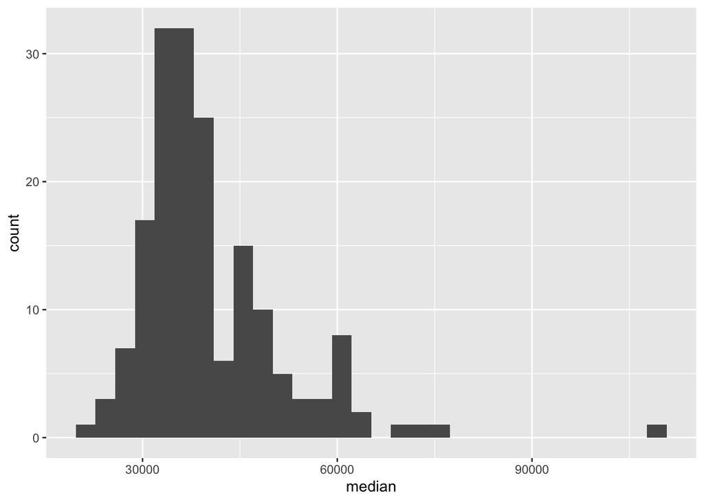

```r
#1.c)
ggplot(data = college_recent_grads, mapping = aes(x = median)) +
  geom_histogram()
```

- **1e.** Try binwidths of $1000 and $5000 and choose one. Explain your reasoning for your choice.

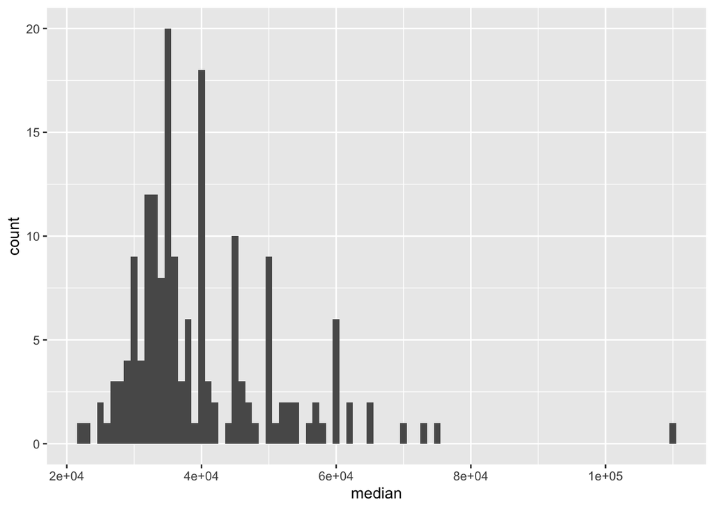

```r
#1.e)
ggplot(data = college_recent_grads, mapping = aes(x = median)) +
  geom_histogram(binwidth = 1000)
```

```r
#I like 1000 more because you get more detail. with 5000 you only get a rough idea of the distribution
```

We can also calculate summary statistics for this distribution using the `summarise` function:

```r
college_recent_grads %>%
  summarise(min = min(median), max = max(median),
            mean = mean(median), med = median(median),
            sd = sd(median),
            q1 = quantile(median, probs = 0.25),
            q3 = quantile(median, probs = 0.75))
```

```
## # A tibble: 1 x 7
##     min    max   mean   med     sd    q1    q3
##   <dbl>  <dbl>  <dbl> <dbl>  <dbl> <dbl> <dbl>
## 1 22000 110000 40151. 36000 11470. 33000 45000
```

```r
#1.f)
#I think the median is the best in describing the distribution
#because the median of 36000 is where, roughly,  the "center of gravity" of the data is.
```

- **1f.** Based on the shape of the histogram you created in the previous 1e, determine which of these summary statistics above (min, max, mean, med, sd, q1, q3) is useful for describing the distribution. Write up your description and include the summary statistic output as well.
- **1g.** Next, we facet the plot by major category. Plot the distribution of `median` income using a histogram, faceted by `major_category`. Use the `binwidth` you chose in 1e.

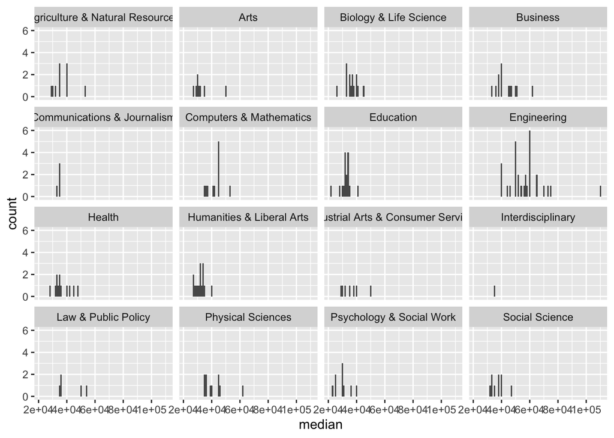

```r
#1.g)
ggplot(data = college_recent_grads, mapping = aes(x = median)) +
  geom_histogram(binwidth = 1000) +
  facet_wrap( ~ major_category, ncol = 4)
```

```r
#I had to comment out my code below because I had knitting issues.

#college_recent_grads %>%
#  print(rank==max())
#Looks like you can get the top paying majors without the  function.
#college_recent_grads %>%
#  (rank==max(1)) %>%
#  glimpse()
#Petroleum Engineering has the highest median earnings at $110,000!
#college_recent_grads %>%
# (rank==max(173)) %>%
#  glimpse()
#The lowest paying is Library Science lol. median pay $22k!
#college_recent_grads %>%
#  (rank==max(87)) %>%
#  glimpse()
#The median pay major is "Human Resources And Personnel Management" at $36k.
```

- **1i.** Which major category is the most popular in this sample? To answer this question we use a new function called `count`, which first groups the data , then counts the number of observations in each category and store the counts into a column named `n`. Add to the pipeline appropriately to arrange the results so that the major with the highest observations is on top.

```r
college_recent_grads %>%
  count(major_category) %>%
  arrange(desc(n))
```

```
## # A tibble: 16 x 2
##    major_category                          n
##    <chr>                               <int>
##  1 Engineering                            29
##  2 Education                              16
##  3 Humanities & Liberal Arts              15
##  4 Biology & Life Science                 14
##  5 Business                               13
##  6 Health                                 12
##  7 Computers & Mathematics                11
##  8 Agriculture & Natural Resources        10
##  9 Physical Sciences                      10
## 10 Psychology & Social Work                9
## 11 Social Science                          9
## 12 Arts                                    8
## 13 Industrial Arts & Consumer Services     7
## 14 Law & Public Policy                     5
## 15 Communications & Journalism             4
## 16 Interdisciplinary                       1
```

```r
#The most popular major category is engineering, followed by education.
```

## What types of majors do women tend to major in?

First, let’s create a new vector called `stem_categories` that lists the major categories that are considered STEM fields.

```r
stem_categories <- c("Biology & Life Science",
                     "Computers & Mathematics",
                     "Engineering",
                     "Physical Sciences")
```

Then, we can use this to create a new variable in our data frame indicating whether a major is STEM or not.

```r
college_recent_grads <- college_recent_grads %>%
  mutate(major_type = ifelse(major_category %in% stem_categories, "stem", "not stem"))
```

Let’s unpack this: with `mutate` we create a new variable called `major_type`, which is defined as `"stem"` if the `major_category` is in the nector called `stem_categories` we created earlier, and as `"not stem"` otherwise.

- **1j.** Create a scatterplot of median income vs. proportion of women in that major, colored by whether the major is in a STEM field or not. Describe the association between these three variables.

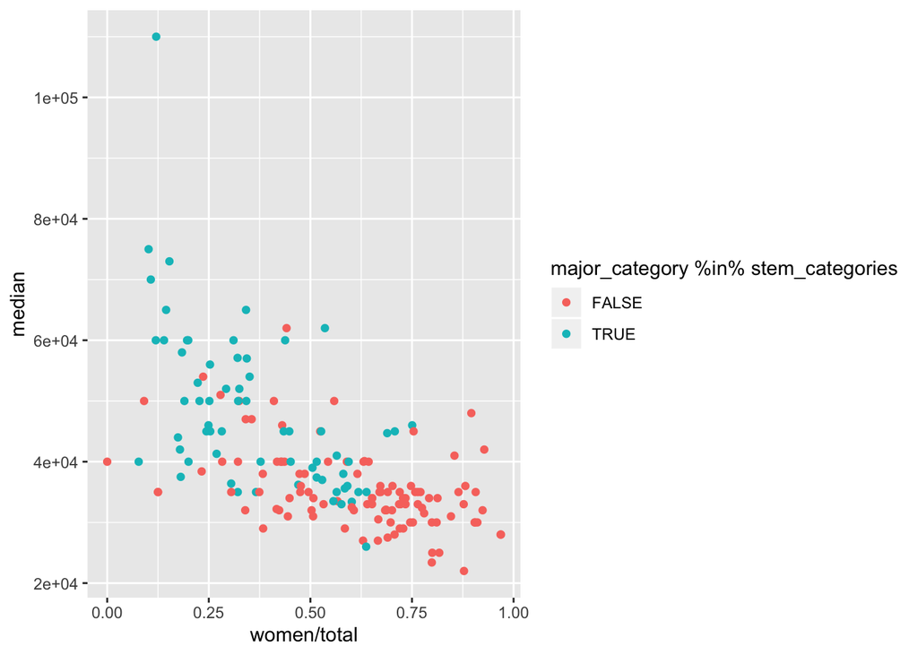

```r
college_recent_grads %>%
  ggplot(aes(x = women / total, y = median)) +  geom_point(aes(color=major_category %in% stem_categories))
```

```r
#Looks like there is an inverse relationship between percentage
#of women in a major and mnedian salary.
#Also non stem fields have a higher percentage of women.
#Stem fields result in the salary.
```

```r
brokestems<-college_recent_grads %>%
  filter(
    major_type == "stem",
    median < 36000
  )
brokenstems2 <- brokestems[,c("major","p25th", "median","p75th")]
print(brokenstems2)
```

```
## # A tibble: 10 x 4
##    major                                 p25th median p75th
##    <chr>                                 <dbl>  <dbl> <dbl>
##  1 Environmental Science                 25000  35600 40200
##  2 Multi-Disciplinary Or General Science 24000  35000 50000
##  3 Physiology                            20000  35000 50000
##  4 Communication Technologies            25000  35000 45000
##  5 Neuroscience                          30000  35000 44000
##  6 Atmospheric Sciences And Meteorology  28000  35000 50000
##  7 Miscellaneous Biology                 23000  33500 48000
##  8 Biology                               24000  33400 45000
##  9 Ecology                               23000  33000 42000
## 10 Zoology                               20000  26000 39000
```